# Лабораторная работа № 9

Презентация

Гайдук Софья Сергеевна

1032253645@rudn.ru

Российский университет дружбы народов

2026-04-11

## Title

# Информация

## Докладчик

- Гайдук Софья Сергеевна
- студент
- Российский университет дружбы народов им. П. Лумумбы
- 1032253645@rudn.ru
- https://github.com/SofiaGayduk/study_2025-2026_os-intro

## Цель работы

Освоение основных возможностей командной оболочки Midnight Commander. Приобретение навыков практической работы по просмотру каталогов и файлов; манипуляций с ними

## Выполнение лабораторной работы

## Задание по mc

Изучим информацию о mc, вызвав в командной строке man mc. Запустим из командной строки mc, изучим его структуру и меню (рис. 1, рис. 2).

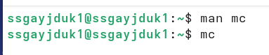

Figure 1: image1

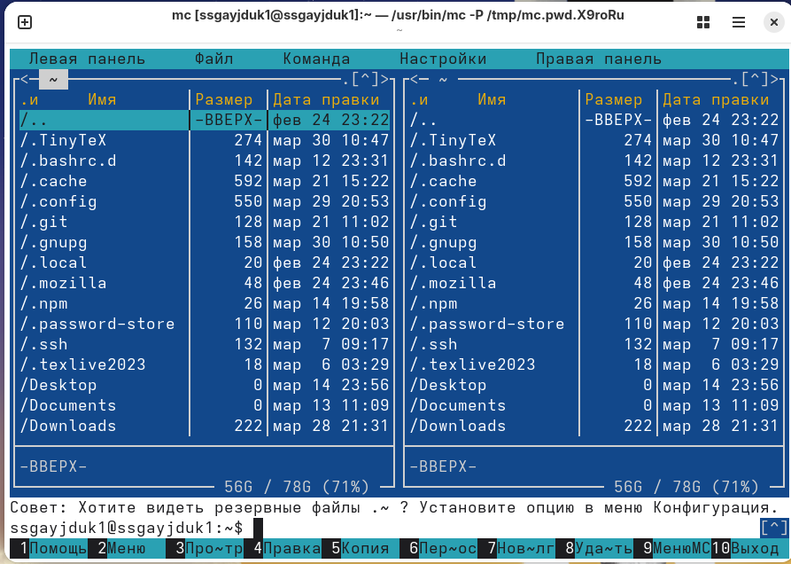

Figure 2: image2

## mc

Выполним несколько операций в mc, используя управляющие клавиши (операции с панелями; выделение/отмена выделения файлов, копирование/перемещение файлов и т.п.) (рис. 3, рис. 4, рис. 5, рис. 6).

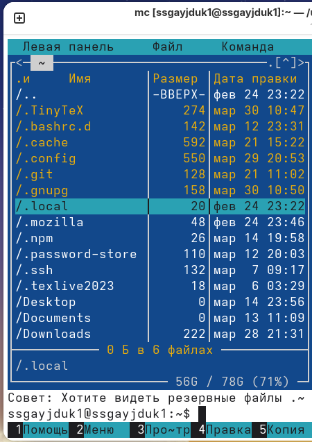

Figure 3: image3

## mc

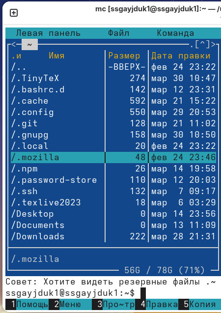

Figure 4: image4

## mc

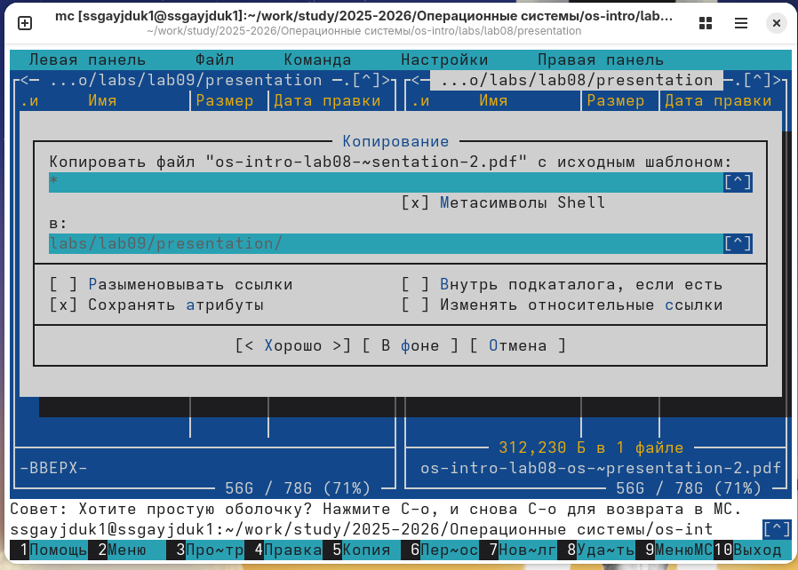

Figure 5: image5

## mc

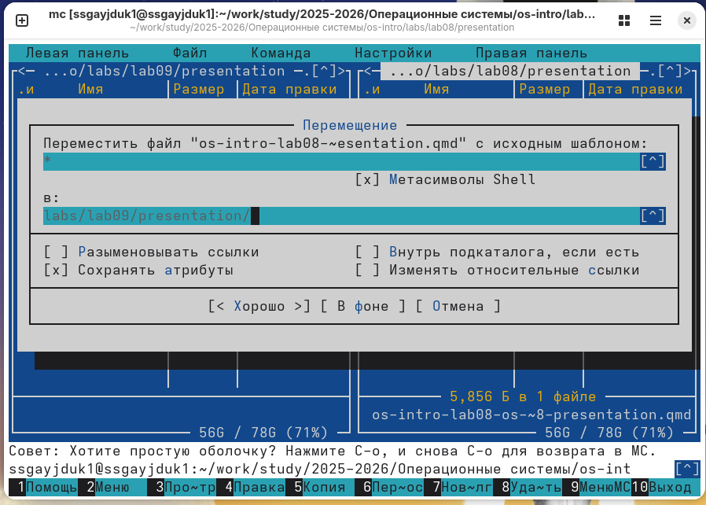

Figure 6: image6

## mc

Выполним основные команды меню левой (или правой) панели. Оценим степень подробности вывода информации о файлах (рис. 7, рис. 8, рис. 9, рис. 10, рис. 11, рис. 12, рис. 13).

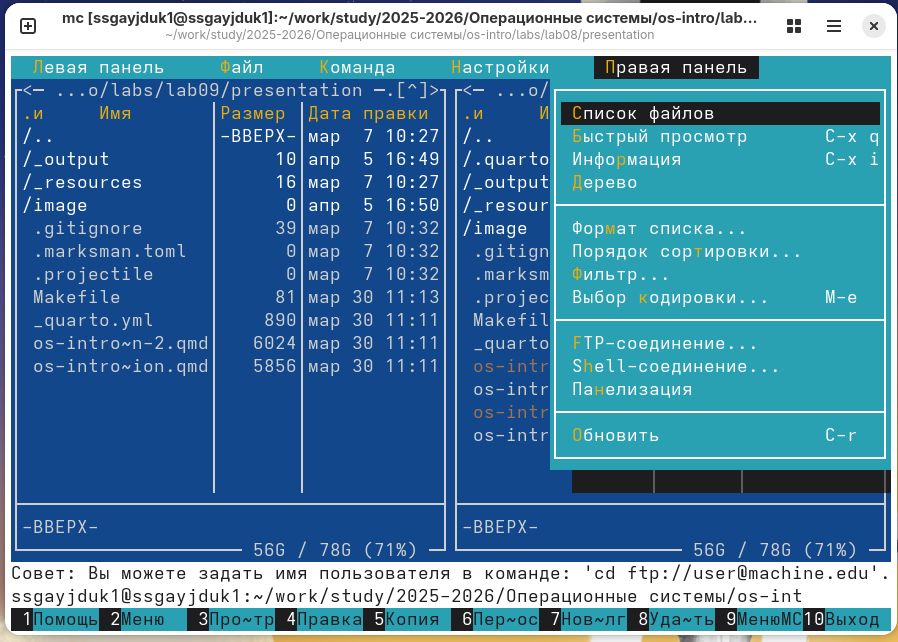

Figure 7: image7

## mc

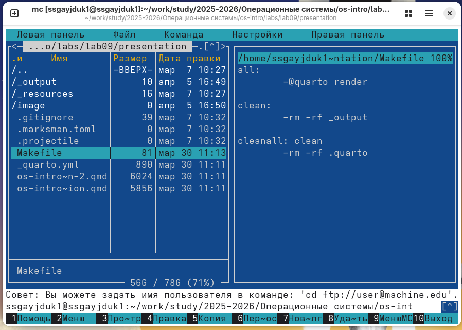

Figure 8: image8

## mc

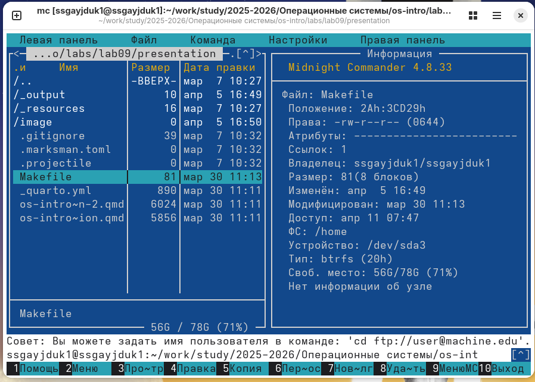

Figure 9: image9

## mc

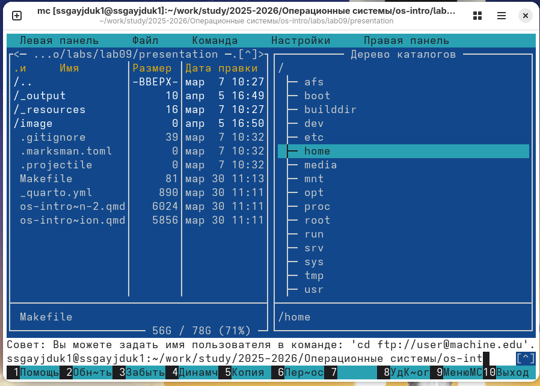

Figure 10: image10

## mc

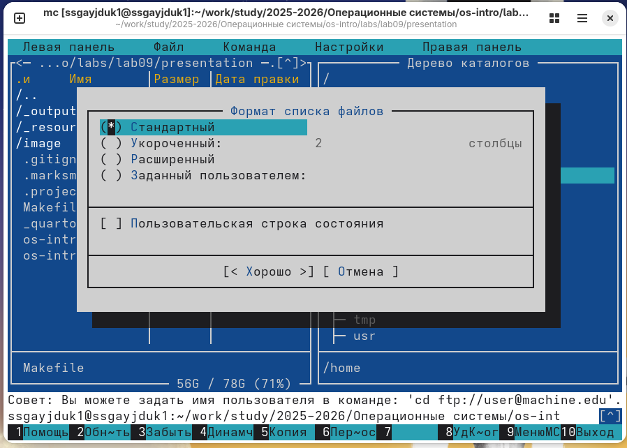

Figure 11: image11

## mc

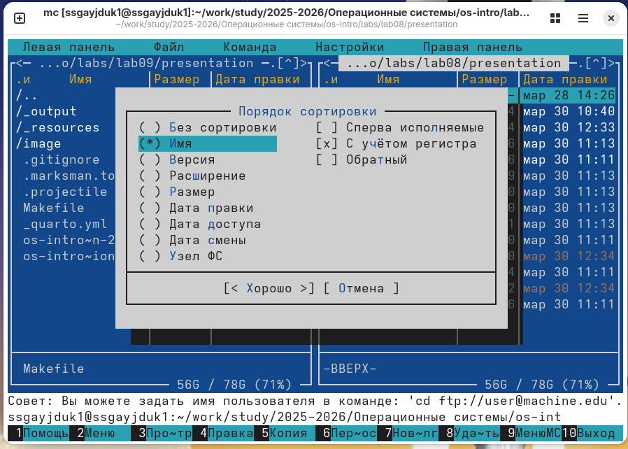

Figure 12: image12

## mc

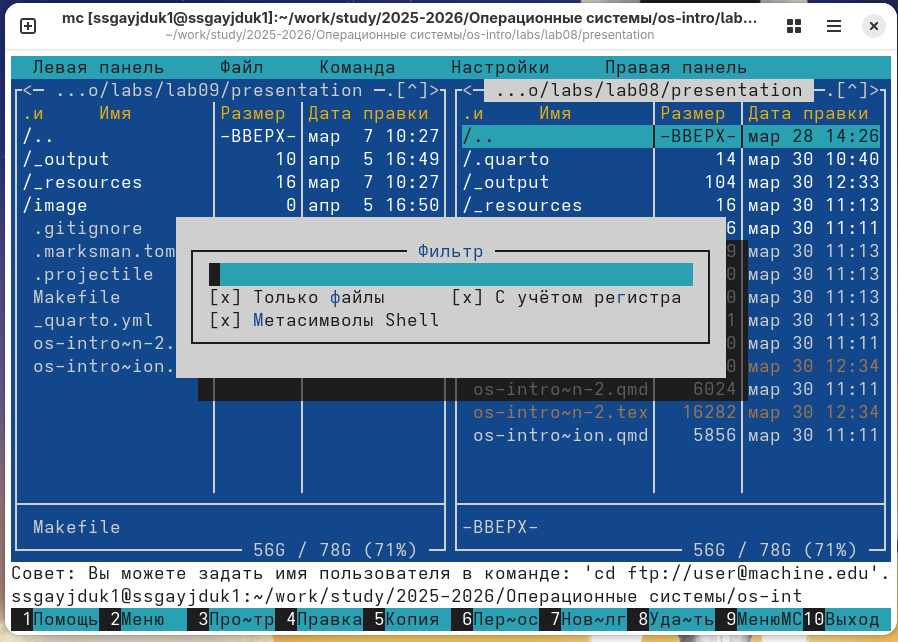

Figure 13: image13

## подменю Файл

Используя возможности подменю Файл , выполним: просмотр содержимого текстового файла, редактирование содержимого текстового файла (без сохранения результатов редактирования), создание каталога, копирование в файлов в созданный каталог (рис. 14, рис. 15, рис. 16, рис. 17, рис. 18, рис. 19).

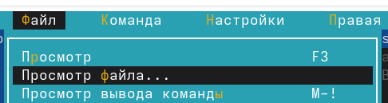

Figure 14: image14

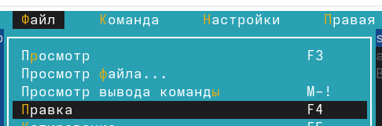

Figure 15: image15

## подменю Файл

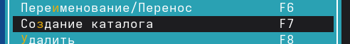

Figure 16: image16

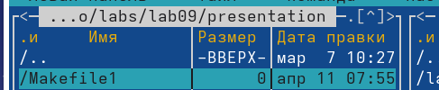

Figure 17: image17

## подменю Файл

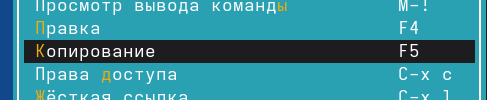

Figure 18: image18

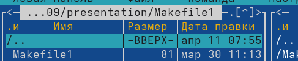

Figure 19: image19

## подменю Команда

С помощью соответствующих средств подменю Команда осуществим: поиск в файловой системе файла с заданными условиями (например, файла с расширением .c или .cpp, содержащего строку main), выбор и повторение одной из предыдущих команд, переход в домашний каталог, анализ файла меню и файла расширений (рис. 20, рис. 21, рис. 22, рис. 23, рис. 24).

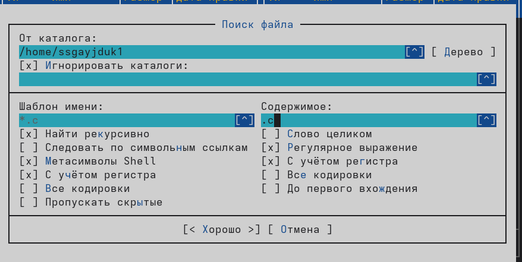

Figure 20: image20

## подменю Команда

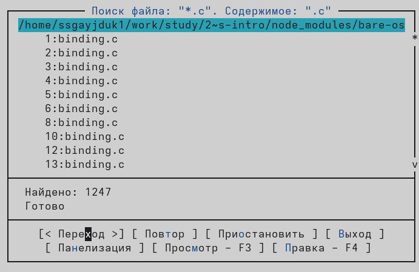

Figure 21: image21

## подменю Команда

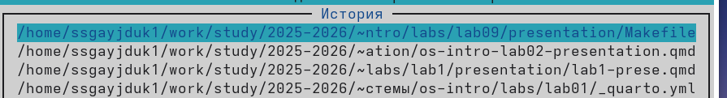

Figure 22: image22

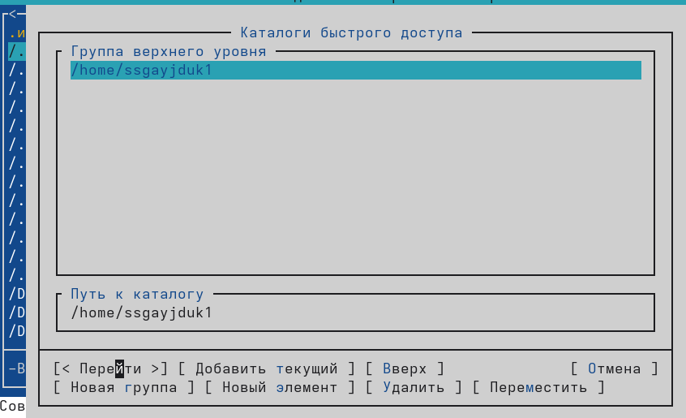

Figure 23: image23

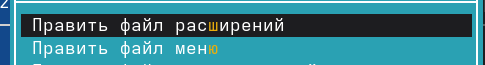

Figure 24: image24

## подменю Настройки

Вызовим подменю Настройки. Освоим операции, определяющие структуру экрана mc (рис. 25, рис. 26, рис. 27, рис. 28, рис. 29).

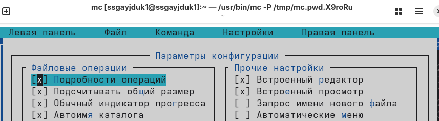

Figure 25: image25

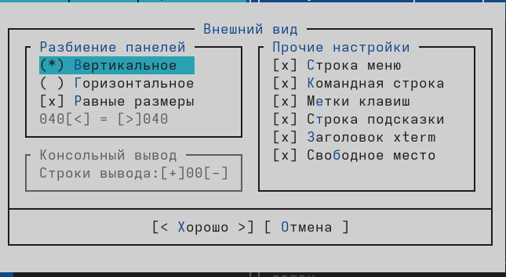

Figure 26: image26

## подменю Настройки

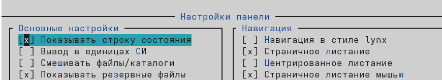

Figure 27: image27

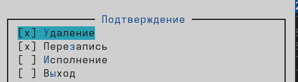

Figure 28: image28

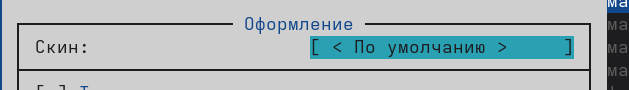

Figure 29: image29